# defining_a_problem

## Exploring the Link Between BMI and Diabetes Risk

**OpenAI. (2025). ChatGPT (Version 4). Assistance with data analysis and visualizations for a diabetes dataset. Retrieved from https://chat.openai.com**

Link to Dataset: [Diabetes patients Uncleaned Data](https://www.kaggle.com/datasets/kabirolawalemohammed/diabetes-unclean)

One of the most common questions in diabetes research is how **Body Mass Index (BMI)** relates to the likelihood of having diabetes. We know that excess body weight can be a risk factor for developing diabetes, but what’s the exact connection? Does a higher BMI correlate with a higher likelihood of being diabetic?

By understanding the relationship between BMI and diabetes risk, this project can provide valuable insights that can be used for **early detection and prevention** of diabetes. The visualizations will help identify high-risk individuals, making it easier to target preventative measures, such as lifestyle changes or medical interventions, at an earlier stage, potentially reducing the burden of diabetes on healthcare systems and improving public health outcomes.

To explore this question, we'll visualize the relationship between **BMI** and **AGE**, with different colors representing the diabetes status (Diabetic vs. Non-Diabetic). By plotting this, we can see if there’s any noticeable pattern between BMI and the likelihood of having diabetes across different age groups.

Additionally, we can further break down this relationship by using histograms to compare the BMI distribution between diabetic and non-diabetic individuals. This will help us understand whether people with higher BMI are more likely to be diabetic, or if other factors come into play.

## Importing Libraries and Datasets

```python
#import libraries
import pandas as pd
import numpy as np
import seaborn as sns
import matplotlib.pyplot as plt
```

## The Data

```python
# import dataset
df = pd.read_csv("diabetes_unclean.csv")
df.head()
```

|  | ID | No_Pation | Gender | AGE | Urea | Cr | HbA1c | Chol | TG | HDL | LDL | VLDL | BMI | CLASS |
| --- | --- | --- | --- | --- | --- | --- | --- | --- | --- | --- | --- | --- | --- | --- |
| 0 | 502 | 17975 | F | 50.0 | 4.7 | 46.0 | 4.9 | 4.2 | 0.9 | 2.4 | 1.4 | 0.5 | 24.0 | N |
| 1 | 735 | 34221 | M | 26.0 | 4.5 | 62.0 | 4.9 | 3.7 | 1.4 | 1.1 | 2.1 | 0.6 | 23.0 | N |
| 2 | 420 | 47975 | F | 50.0 | 4.7 | 46.0 | 4.9 | 4.2 | 0.9 | 2.4 | 1.4 | 0.5 | 24.0 | N |
| 3 | 680 | 87656 | F | 50.0 | 4.7 | 46.0 | 4.9 | 4.2 | 0.9 | 2.4 | 1.4 | 0.5 | 24.0 | N |
| 4 | 504 | 34223 | M | 33.0 | 7.1 | 46.0 | 4.9 | 4.9 | 1.0 | 0.8 | 2.0 | 0.4 | 21.0 | N |

```python
df.info()
```

```
<class 'pandas.core.frame.DataFrame'>
RangeIndex: 1009 entries, 0 to 1008
Data columns (total 14 columns):
 #   Column     Non-Null Count  Dtype
---  ------     --------------  -----
 0   ID         1009 non-null   int64
 1   No_Pation  1009 non-null   int64
 2   Gender     1009 non-null   object
 3   AGE        1008 non-null   float64
 4   Urea       1008 non-null   float64
 5   Cr         1007 non-null   float64
 6   HbA1c      1006 non-null   float64
 7   Chol       1007 non-null   float64
 8   TG         1007 non-null   float64
 9   HDL        1008 non-null   float64
 10  LDL        1007 non-null   float64
 11  VLDL       1008 non-null   float64
 12  BMI        1009 non-null   float64
 13  CLASS      1009 non-null   object
dtypes: float64(10), int64(2), object(2)
memory usage: 110.5+ KB
```

## Scrubbing and Cleaning the data

### Kicking Off the Data Cleaning Process

Before we can begin analyzing our data, it's essential to clean it up and remove any unnecessary clutter. At the start of our cleaning process, we focus on dropping irrelevant columns that won’t contribute to our analysis.

In this step, we're removing the **ID** and **No_Pation** columns. The **ID** column usually serves as a unique identifier for each entry, but it doesn't add any value for our analysis. Similarly, **No_Pation** appears to be a label or reference number, which we also don’t need for exploring relationships or patterns in the data.

By dropping these columns, we’re streamlining the dataset and keeping only the information that matters for our analysis going forward.

```python
# drop the ID and No_Pation columns
cleaned_df = df
cleaned_df.drop(columns=['ID'], inplace=True)
cleaned_df.drop(columns=['No_Pation'], inplace=True)
cleaned_df.head(2)
```

|  | Gender | AGE | Urea | Cr | HbA1c | Chol | TG | HDL | LDL | VLDL | BMI | CLASS |
| --- | --- | --- | --- | --- | --- | --- | --- | --- | --- | --- | --- | --- |
| 0 | F | 50.0 | 4.7 | 46.0 | 4.9 | 4.2 | 0.9 | 2.4 | 1.4 | 0.5 | 24.0 | N |
| 1 | M | 26.0 | 4.5 | 62.0 | 4.9 | 3.7 | 1.4 | 1.1 | 2.1 | 0.6 | 23.0 | N |

### Checking for Missing Values

Now that we’ve cleaned up some unnecessary columns, the next step is to ensure that our dataset is complete. **Missing values** can be a common issue in many datasets, and they can cause problems during analysis or modeling if not handled properly.

In this step, we check for any missing values across the entire dataset by using the `isnull()` function. This function will tell us if any values are missing in each column. We then use `sum()` to count how many missing values there are in each column, giving us a clear picture of where the data might be incomplete.

Once we know where the missing values are, we can decide on the best way to handle them—whether by filling them in, removing rows, or using other techniques. This ensures that we can continue with our analysis without any interruptions or biases caused by missing data.

```python
# check for missing values
cleaned_df.isnull().sum()
```

```
Gender    0
AGE       1
Urea      1
Cr        2
HbA1c     3
Chol      2
TG        2
HDL       1
LDL       2
VLDL      1
BMI       0
CLASS     0
dtype: int64
```

### Handling Missing Values: Why Dropping Rows Makes Sense

After checking for missing values in our dataset, we can see that only a few entries are incomplete. Specifically, columns like **AGE**, **Urea**, and **HbA1c** have a small number of missing values—ranging from 1 to 3 missing entries in each column.

Given that such a small percentage of the data is missing (just a few rows across several columns), **dropping the rows with missing values** is a reasonable choice. This is especially true because:

1. **Minimal Data Loss**: Since only a small number of rows contain missing values, removing them won’t significantly impact the size or quality of the dataset. We’re not losing a large amount of data, and the remaining dataset is still robust enough for analysis.
2. **Simplicity**: Dropping missing values is a quick and straightforward approach, which is often preferred when the missing data is minimal. It avoids the complexities of imputation or filling missing values, which could introduce bias if not handled carefully.
3. **Preserving Data Integrity**: By removing rows with missing values, we’re ensuring that every entry in the dataset is complete, which is especially important when preparing the data for analysis or modeling. This way, we avoid potential issues that could arise from using incomplete rows.

After dropping these rows, we can see from the output that there are no missing values left in the dataset. This leaves us with a clean, fully populated dataset, ready to move on to the next steps in our analysis.

```python
# drop rows with missing values
cleaned_df = cleaned_df.dropna()
cleaned_df.isnull().sum()
```

```
Gender    0
AGE       0
Urea      0
Cr        0
HbA1c     0
Chol      0
TG        0
HDL       0
LDL       0
VLDL      0
BMI       0
CLASS     0
dtype: int64
```

### Checking and Removing Duplicate Rows

At this point, we want to ensure that our dataset is free of duplicate entries, as these can skew our analysis and give misleading results.

We start by checking for any duplicates in the data. The code will count how many rows are duplicated, so we can see if we need to clean anything up. In our case, we find that there are **169 duplicate rows** in the dataset.

```python
# check for duplicates
print("Duplicates found: ", cleaned_df.duplicated().sum(), "rows")
```

```
Duplicates found:  169 rows
```

Now, it's time to clean things up. We drop those duplicate rows, leaving us with only unique entries. Once the duplicates are removed, we re-check to confirm that there are no more duplicates.

With the duplicates gone, we can now move on with a clean and consistent dataset, ready for further analysis.

```python
# 169 rows are duplicated
# drop duplicates
final_df = cleaned_df
final_df = final_df.drop_duplicates()
final_df.duplicated().sum()
final_df.head(2)
```

|  | Gender | AGE | Urea | Cr | HbA1c | Chol | TG | HDL | LDL | VLDL | BMI | CLASS |
| --- | --- | --- | --- | --- | --- | --- | --- | --- | --- | --- | --- | --- |
| 0 | F | 50.0 | 4.7 | 46.0 | 4.9 | 4.2 | 0.9 | 2.4 | 1.4 | 0.5 | 24.0 | N |
| 1 | M | 26.0 | 4.5 | 62.0 | 4.9 | 3.7 | 1.4 | 1.1 | 2.1 | 0.6 | 23.0 | N |

## Converting Categories into Dummy Variables

Now that we’ve cleaned up our dataset, it’s time to convert categorical data into a format that’s easier for analysis. In particular, we’re focusing on the **Gender** and **CLASS** columns.

We’ll start by converting the **Gender** column into **dummy variables**. This will create separate columns for each gender, making it easier for us to analyze the relationship between gender and other factors. Each row will get a 1 or 0 in the respective gender column, indicating whether a person is male, female, or any other category.

Next, we’ll do the same thing with the **CLASS** column, which holds the diabetes status of the individuals. We’ll turn this into dummy variables as well, so instead of just having values like "Y" or "N," we’ll get separate columns for each possible class (such as diabetic, non-diabetic, and pre-diabetic), again using 1s and 0s to represent each category.

Finally, after converting these columns into dummy variables, we’ll drop the original **Gender** column, as it’s no longer needed in its original form.

With these transformations, our dataset is now in a much more analyzable format!

```python
# convert the Gender column to dummy variables
final_df = pd.get_dummies(final_df, columns=['Gender'], prefix='', dtype=int)
final_df = pd.get_dummies(final_df, columns=['CLASS'], prefix='', dtype=int)
# now lets drop the original Gender column
#final_df.drop(columns=['Gender'], inplace=True)
final_df.head(2)
```

|  | AGE | Urea | Cr | HbA1c | Chol | TG | HDL | LDL | VLDL | BMI | _F | _M | _f | _N | _N | _P | _Y | _Y |
| --- | --- | --- | --- | --- | --- | --- | --- | --- | --- | --- | --- | --- | --- | --- | --- | --- | --- | --- |
| 0 | 50.0 | 4.7 | 46.0 | 4.9 | 4.2 | 0.9 | 2.4 | 1.4 | 0.5 | 24.0 | 1 | 0 | 0 | 1 | 0 | 0 | 0 | 0 |
| 1 | 26.0 | 4.5 | 62.0 | 4.9 | 3.7 | 1.4 | 1.1 | 2.1 | 0.6 | 23.0 | 0 | 1 | 0 | 1 | 0 | 0 | 0 | 0 |

## Tidying Up the Dataset for Easier Analysis

As we dive deeper into our analysis, we realize that our dataset could use a little tidying up. We have some columns that could be combined, and a few that could use more intuitive names. So, we’re going to clean things up a bit to make everything more manageable.

First, we notice that we have two columns representing the **female** gender—one with an uppercase "F" and the other with a lowercase "f." We don't need both, so we’re going to merge them into a single column called **Female**.

Next, we have a couple of columns that show whether a person is diabetic or not, but they’re spread across two columns each—one for **non-diabetic** status and another for **diabetic** status. To simplify, we’re combining them into just two columns: **NonDiabetic** and **Diabetic**. This will make it so much easier to work with going forward.

We also want to make the column names more intuitive. The column that shows **male** gender will be renamed to just **Male**, and the column that represents those in the **pre-diabetic** stage will be renamed to **PreDiabetes**.

By the end of this process, our dataset will be much cleaner, with all the information we need neatly organized and ready for deeper analysis.

```python
# Combine columns _F and _f into a single column called Female
final_df['Female'] = final_df['_F'] + final_df['_f']
final_df.drop(columns=['_F', '_f'], inplace=True)

# Combine columns _N and _N into a single column called NonDiabetic
final_df['NonDiabetic'] = final_df['_N'] + final_df['_N ']
final_df.drop(columns=['_N', '_N '], inplace=True)

# Combine columns _Y and _Y into a single column called Diabetic
final_df['Diabetic'] = final_df['_Y'] + final_df['_Y ']
final_df.drop(columns=['_Y', '_Y '], inplace=True)

# Rename column _M to Male
final_df.rename(columns={'_M': 'Male'}, inplace=True)

# Rename column _P to PreDiabetes
final_df.rename(columns={'_P': 'PreDiabetes'}, inplace=True)

# Display the first two rows of the DataFrame
final_df.head(2)
```

|  | AGE | Urea | Cr | HbA1c | Chol | TG | HDL | LDL | VLDL | BMI | Male | PreDiabetes | Female | NonDiabetic | Diabetic |
| --- | --- | --- | --- | --- | --- | --- | --- | --- | --- | --- | --- | --- | --- | --- | --- |
| 0 | 50.0 | 4.7 | 46.0 | 4.9 | 4.2 | 0.9 | 2.4 | 1.4 | 0.5 | 24.0 | 0 | 0 | 1 | 1 | 0 |
| 1 | 26.0 | 4.5 | 62.0 | 4.9 | 3.7 | 1.4 | 1.1 | 2.1 | 0.6 | 23.0 | 1 | 0 | 0 | 1 | 0 |

## Uncovering Relationships in the Data: The Correlation Matrix

To understand how different factors in our dataset relate to each other, we use a correlation matrix. This helps us identify strong connections between features. For example, BMI has a strong positive correlation with diabetes status (0.589) and a moderate positive correlation with HbA1c (0.455). This suggests that individuals with higher BMI are more likely to be diabetic and may have higher HbA1c levels, a key marker in diabetes risk. Additionally, age shows a moderate positive correlation with diabetes status (0.478), highlighting that older individuals are more likely to develop diabetes. HbA1c also strongly correlates with diabetes status (0.567), confirming the importance of HbA1c levels in predicting diabetes. These key correlations—particularly between BMI, HbA1c, age, and diabetes status—will guide our next visualization, where we will explore how these features interact in more detail.

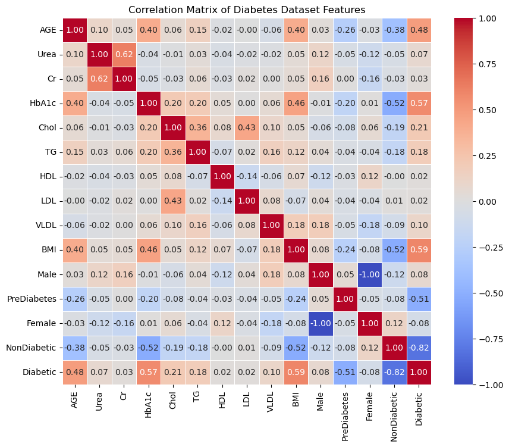

```python
# Calculate the correlation matrix
corr_matrix = final_df.corr()

# Plot the correlation matrix using a heatmap
plt.figure(figsize=(10, 8))
sns.heatmap(corr_matrix, annot=True, cmap='coolwarm', fmt=".2f", linewidths=0.5, vmin=-1, vmax=1)
plt.title('Correlation Matrix of Diabetes Dataset Features')
plt.show()
```

## Analyzing Key Relationships: Correlation Between AGE, BMI, HbA1c, and Diabetes Status

As we dug deeper into the data, we decided to zoom in on four key factors that we believed had a major impact on diabetes risk: **AGE, BMI, HbA1c, and Diabetic status**. These are all important markers when trying to assess someone’s likelihood of developing diabetes, so understanding how they relate to one another was critical. We started by calculating the correlation between these variables, which gave us a clearer picture of their connections. What we found was telling:

- There’s a strong positive relationship between BMI and Diabetic status (0.589). This makes sense: higher BMI is often linked with a higher risk of developing diabetes, which is what we’re seeing here.
- BMI and HbA1c are also moderately correlated (0.455), further supporting the idea that individuals with higher BMI tend to have elevated HbA1c levels, another key indicator of diabetes.
- We also found that AGE has a moderate positive correlation with Diabetic status (0.478), indicating that as people get older, the likelihood of being diabetic increases—a well-known trend in diabetes research.
- Lastly, HbA1c and Diabetic status showed a strong correlation (0.567), emphasizing the role HbA1c plays in diagnosing and predicting diabetes.

By visualizing these correlations in a heatmap, we could easily spot these connections and understand how each factor plays a role in the bigger picture of diabetes risk. This insight sets the stage for our next step, where we’ll dive deeper into how BMI, AGE, and HbA1c interact with one another to better understand the full scope of diabetes risk.

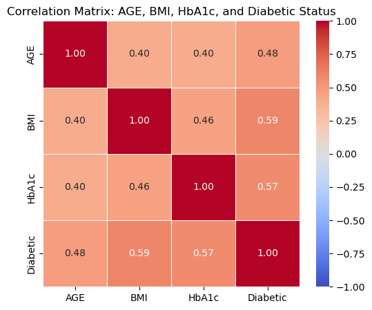

```python
corr_matrix = final_df[['AGE', 'BMI', 'HbA1c', 'Diabetic']].corr()

plt.figure(figsize=(6, 5))
sns.heatmap(corr_matrix, annot=True, cmap='coolwarm', fmt=".2f", linewidths=0.5, vmin=-1, vmax=1)
plt.title('Correlation Matrix: AGE, BMI, HbA1c, and Diabetic Status')
plt.show()
```

## Analyzing HbA1c Distribution by Diabetes Status

n the box plot, the x-axis represents Diabetes Status, where 0 corresponds to non-diabetic individuals and 1 corresponds to those with diabetes. The y-axis displays HbA1c levels, which are crucial for understanding blood sugar control. For the Non-Diabetic group (represented by 0), the box plot shows that most HbA1c values fall between 4.3 and 5.8, with the median around 5.0. This indicates that non-diabetic individuals typically have normal blood sugar levels. In contrast, the Diabetic group (represented by 1) has a much higher spread of HbA1c values, ranging from 2.0 to 16.0. The bulk of the data falls between 7.3 and 10.6, with the median at 8.9. The plot also shows a few extreme outliers, with some individuals having HbA1c values as high as 16.0, reflecting poorly controlled blood sugar. This comparison between the two groups visually highlights how much more variable and higher HbA1c levels are in individuals with diabetes compared to those without.

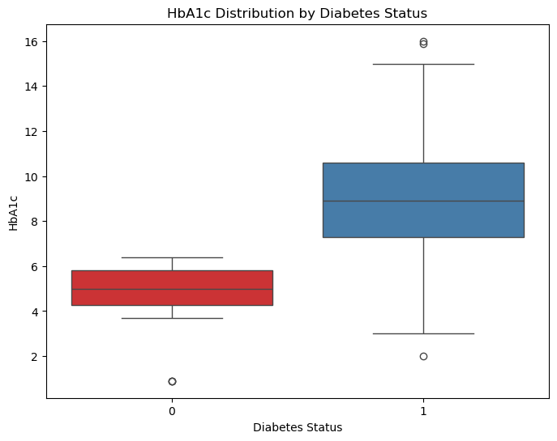

```python
plt.figure(figsize=(8, 6))
sns.boxplot(x='Diabetic', y='HbA1c', data=final_df, palette='Set1')
plt.title('HbA1c Distribution by Diabetes Status')
plt.xlabel('Diabetes Status')
plt.ylabel('HbA1c')
plt.show()
```

## Distribution of BMI by Diabetes Status

To understand how Body Mass Index (BMI) differs across various diabetes statuses, we’ve plotted histograms for three groups: Diabetic, NonDiabetic, and PreDiabetes individuals.

- Diabetic individuals are represented in red.
- NonDiabetic individuals are represented in blue.PreDiabetes individuals are represented in green.Each histogram displays the spread of BMI values for each group, with the KDE (Kernel Density Estimate) curve providing a smooth estimation of the distribution.

**Looking at the data**:

- Diabetic individuals tend to have a higher average BMI (30.82) with a range from 19.0 to 47.75. The BMI for this group is more spread out, with a noticeable peak around 30.0, showing that a significant portion of diabetic individuals fall within the higher BMI range.

-NonDiabetic individuals have a lower average BMI (22.35) and a tighter distribution, with a range from 19.0 to 24.60. This group shows a concentration of BMI values around 22.0, which suggests that most non-diabetic individuals fall within a normal BMI range.

- PreDiabetes individuals have an average BMI of 24.11, with a range from 19.0 to 32.0. The distribution shows a slight shift toward higher BMI compared to non-diabetics, but not as high as the diabetic group.

These histograms make it clear that Diabetic individuals generally have higher BMIs than NonDiabetic individuals, with PreDiabetes falling somewhere in between. This pattern suggests a relationship between higher BMI and an increased likelihood of developing diabetes, which is something to consider for further analysis.

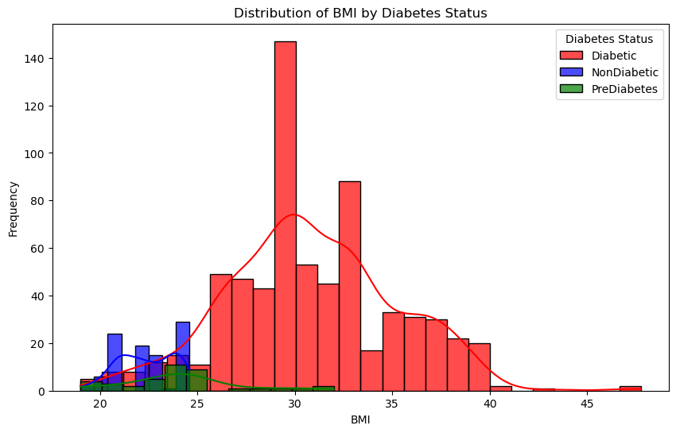

```python
# Plot histograms of BMI for Diabetic, NonDiabetic, and PreDiabetes individuals
plt.figure(figsize=(10, 6))

# Histogram for Diabetic individuals
sns.histplot(data=final_df[final_df['Diabetic'] == 1], x='BMI', color='red', label='Diabetic', kde=True, alpha=0.7)

# Histogram for NonDiabetic individuals
sns.histplot(data=final_df[final_df['NonDiabetic'] == 1], x='BMI', color='blue', label='NonDiabetic', kde=True, alpha=0.7)

# Histogram for PreDiabetes individuals
sns.histplot(data=final_df[final_df['PreDiabetes'] == 1], x='BMI', color='green', label='PreDiabetes', kde=True, alpha=0.7)

plt.title('Distribution of BMI by Diabetes Status')
plt.xlabel('BMI')
plt.ylabel('Frequency')
plt.legend(title='Diabetes Status')
plt.show()
```

## BMI vs AGE by Diabetes Status

To explore how BMI and AGE are related to diabetes status, we’ve created a scatter plot that shows the relationship between these two variables across three groups: Diabetic, NonDiabetic, and PreDiabetes individuals.

Each point on the scatter plot represents an individual, with their AGE on the x-axis and their BMI on the y-axis. A horizontal line at BMI = 25 is included to highlight the threshold between normal weight and overweight.

The plot allows us to examine how BMI and age correlate with diabetes status and identify trends among different groups.

Key observations:

Diabetic individuals tend to have a higher BMI and are generally older. NonDiabetic individuals usually have a lower BMI and are younger. PreDiabetes individuals fall in between, with BMI values suggesting an increased risk of developing diabetes.

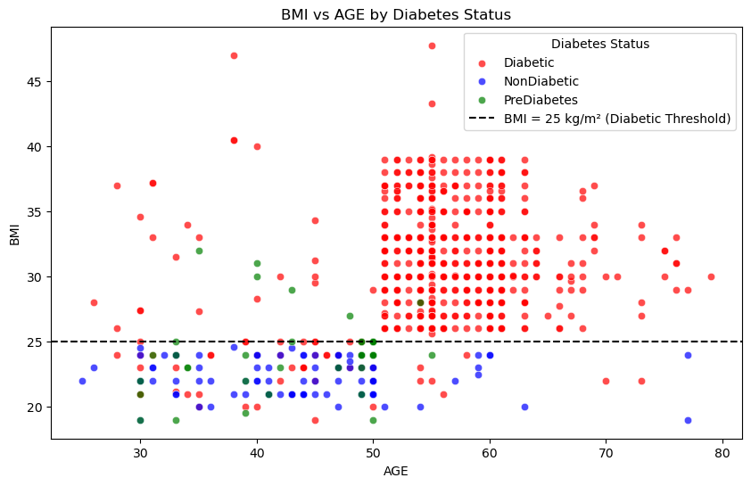

```python
# Scatter plot of BMI vs AGE by Diabetic, NonDiabetic, and PreDiabetes status
plt.figure(figsize=(10, 6))

# Scatter plot for Diabetic individuals
sns.scatterplot(data=final_df[final_df['Diabetic'] == 1], x='AGE', y='BMI', color='red', label='Diabetic', alpha=0.7)

# Scatter plot for NonDiabetic individuals
sns.scatterplot(data=final_df[final_df['NonDiabetic'] == 1], x='AGE', y='BMI', color='blue', label='NonDiabetic', alpha=0.7)

# Scatter plot for PreDiabetes individuals
sns.scatterplot(data=final_df[final_df['PreDiabetes'] == 1], x='AGE', y='BMI', color='green', label='PreDiabetes', alpha=0.7)

# Draw a horizontal line at a specific BMI value (e.g., BMI = 30)
plt.axhline(y=25, color='black', linestyle='--', label='BMI = 25 kg/m² (Diabetic Threshold)')

# Adding labels and title
plt.title('BMI vs AGE by Diabetes Status')
plt.xlabel('AGE')
plt.ylabel('BMI')
plt.legend(title='Diabetes Status')

# Show plot
plt.show()
```

## AGE vs HbA1c by Diabetes Status

In this visualization, we’ve included a horizontal line at HbA1c = 6.5%, which is the typical threshold for diagnosing diabetes. This line serves as an important reference point, helping us identify individuals whose HbA1c levels are indicative of diabetes.

The scatter plot allows us to explore the interaction between AGE and HbA1c, shedding light on whether certain age groups are more likely to exceed this threshold and experience poor blood sugar control.

By examining the plot, we can assess patterns such as:

Are older individuals more likely to have higher HbA1c levels? Do Diabetic individuals have higher HbA1c levels compared to NonDiabetic individuals? How does PreDiabetes compare in terms of age and HbA1c distribution?

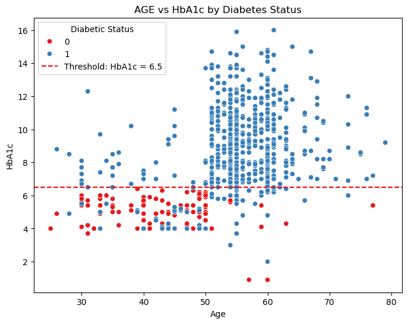

```python
# Scatter plot of AGE vs HbA1c, colored by Diabetes status
plt.figure(figsize=(8, 6))
sns.scatterplot(x='AGE', y='HbA1c', hue='Diabetic', data=final_df, palette='Set1')

# Draw a horizontal line at a specific HbA1c value (e.g., 6.5)
plt.axhline(y=6.5, color='red', linestyle='--', label='Threshold: HbA1c = 6.5')

# Adding labels and title
plt.title('AGE vs HbA1c by Diabetes Status')
plt.xlabel('Age')
plt.ylabel('HbA1c')
plt.legend(title='Diabetic Status')

# Show plot
plt.show()
```

## HbA1c vs BMI by Diabetes Status

In this scatter plot, we explore the relationship between HbA1c and BMI for individuals categorized as Diabetic, NonDiabetic, and PreDiabetes. Different colors represent each group: red for Diabetic, blue for NonDiabetic, and green for PreDiabetes.

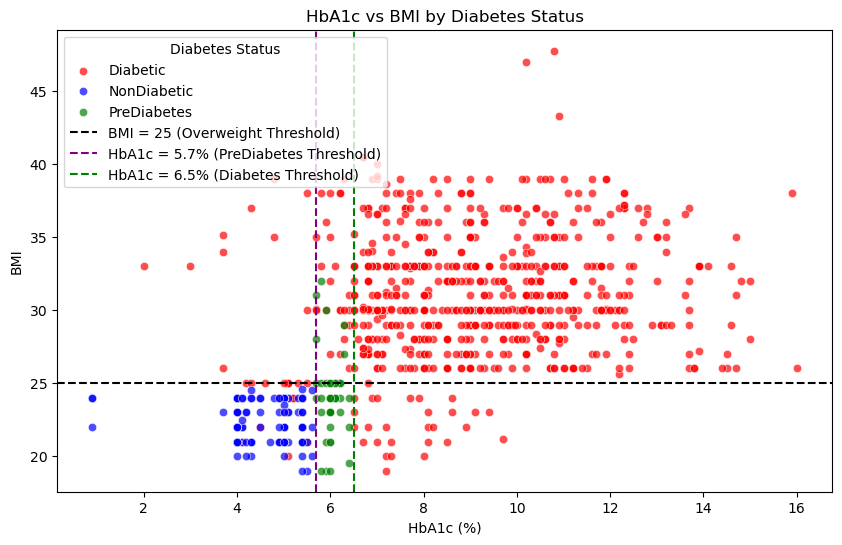

```python
# Scatter plot of HbA1c vs BMI by Diabetic, NonDiabetic, and PreDiabetes status
plt.figure(figsize=(10, 6))

# Scatter plot for Diabetic individuals
sns.scatterplot(data=final_df[final_df['Diabetic'] == 1], x='HbA1c', y='BMI', color='red', label='Diabetic', alpha=0.7)

# Scatter plot for NonDiabetic individuals
sns.scatterplot(data=final_df[final_df['NonDiabetic'] == 1], x='HbA1c', y='BMI', color='blue', label='NonDiabetic', alpha=0.7)

# Scatter plot for PreDiabetes individuals
sns.scatterplot(data=final_df[final_df['PreDiabetes'] == 1], x='HbA1c', y='BMI', color='green', label='PreDiabetes', alpha=0.7)

# Draw a horizontal line at BMI = 25 (overweight threshold)
plt.axhline(y=25, color='black', linestyle='--', label='BMI = 25 (Overweight Threshold)')

# Draw vertical lines for HbA1c thresholds
plt.axvline(x=5.7, color='purple', linestyle='--', label='HbA1c = 5.7% (PreDiabetes Threshold)')
plt.axvline(x=6.5, color='green', linestyle='--', label='HbA1c = 6.5% (Diabetes Threshold)')

# Adding labels and title
plt.title('HbA1c vs BMI by Diabetes Status')
plt.xlabel('HbA1c (%)')
plt.ylabel('BMI')
plt.legend(title='Diabetes Status')

# Show plot
plt.show()
```

Throughout this project, we explored diabetes risk factors using scatter plots, correlation matrices, and histograms. The scatter plot demonstrated how BMI and HbA1c interact across different diabetes statuses, with Diabetic individuals tending to have higher BMI and HbA1c values.

The correlation matrix provided quantitative confirmation of these relationships. It revealed a moderate positive correlation between BMI and HbA1c (0.46), suggesting that individuals with higher BMI often have elevated HbA1c levels. Additionally, we found that AGE correlates more strongly with Diabetic status (0.48), indicating that older individuals are more likely to be diabetic. The histograms further reinforced these trends, showing that Diabetic individuals generally have higher BMI values, while NonDiabetic individuals have lower, more concentrated BMI distributions.

Reflecting on this project, it has been an insightful learning experience, reinforcing the power of data visualization and statistical analysis in understanding health data. The combination of scatter plots, correlation matrices, and histograms allowed us to build a comprehensive picture of diabetes risk factors. This analysis highlights the importance of considering multiple factors—BMI, HbA1c, and AGE—when assessing diabetes risk. The patterns observed suggest that individuals with higher BMI and HbA1c are at greater risk, and AGE plays a significant role in this likelihood.

This project underscored the importance of multidimensional analysis in medical research and the value of using data-driven insights to inform healthcare decisions. Understanding the interplay between BMI, HbA1c, and AGE can help guide future research and improve risk assessment strategies for diabetes prevention and management.